# examples_0406

In Adams, Massachusetts, 4 candidates (W through Z) are running in an election with a single winner. There are 7 voters (A through G) who each rank the candidates from 1 to 4, with 1 meaning first choice and 4 meaning last choice. Those rankings are shown below. Each column represents a single voter's ranking.

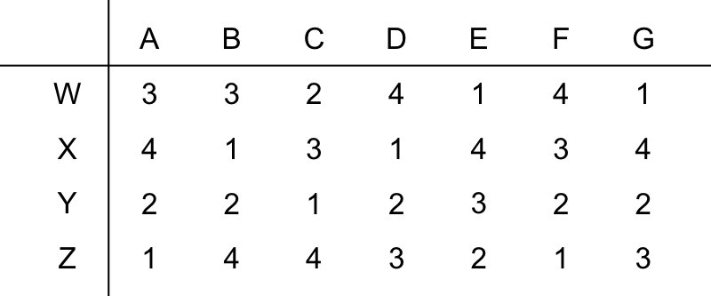

A [Condorcet winner](https://en.wikipedia.org/wiki/Condorcet_method) would win in a head-to-head election against any other candidate. Who is the Condorcet winner? (Or, possibly, there is none.)

WXYZNo Condorcet winner!

Consider every head-to-head election. With 4 candidates, there will be ${4\choose 2 }= 6$ pairings (see [combinations](https://en.wikipedia.org/wiki/Binomial_coefficient)).

Compare candidates W and X.

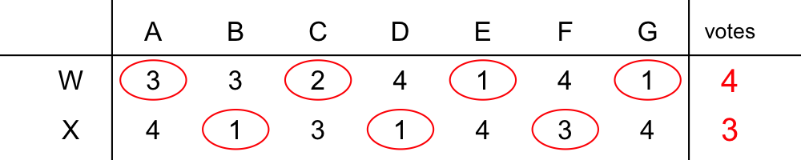

So, W beats X.

Compare candidates W and Y.

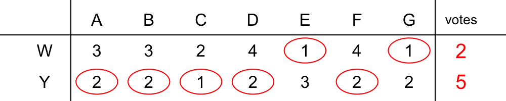

So, Y beats W.

Compare candidates W and Z.

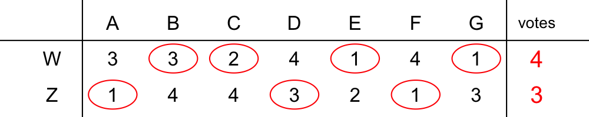

So, W beats Z.

Compare candidates X and Y.

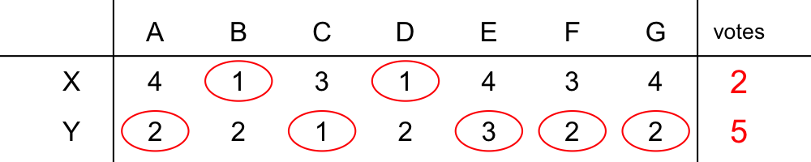

So, Y beats X.

Compare candidates X and Z.

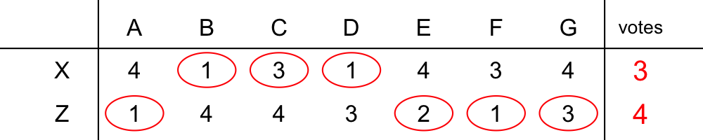

So, Z beats X.

Compare candidates Y and Z.

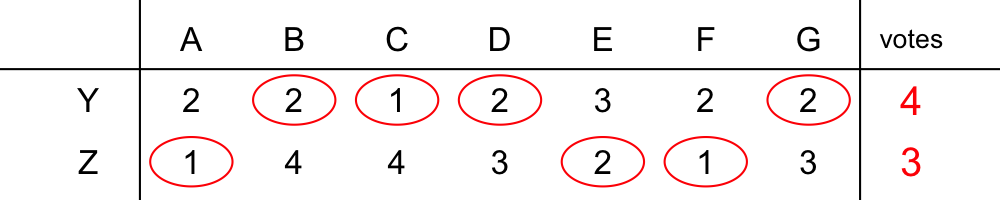

So, Y beats Z.

Organize all this into a winner table.

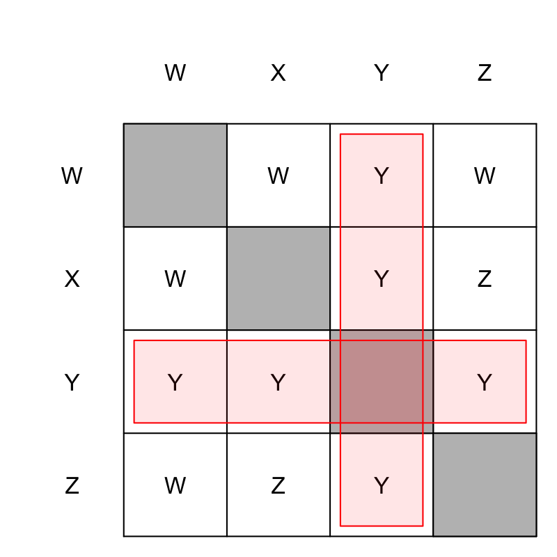

Notice Y wins against all other candidates. Thus Y is the Condorcet winner.

In Adams, Massachusetts, 4 candidates (W through Z) are running in an election with a single winner. There are 7 voters (A through G) who each rank the candidates from 1 to 4, with 1 meaning first choice and 4 meaning last choice. Those rankings are shown below. Each column represents a single voter's ranking.

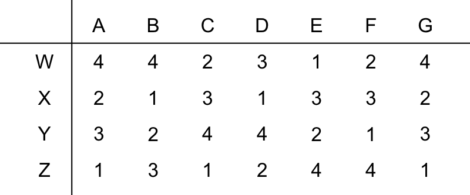

A [Condorcet winner](https://en.wikipedia.org/wiki/Condorcet_method) would win in a head-to-head election against any other candidate. Who is the Condorcet winner? (Or, possibly, there is none.)

WXYZNo Condorcet winner!

Consider every head-to-head election. With 4 candidates, there will be ${4\choose 2 }= 6$ pairings (see [combinations](https://en.wikipedia.org/wiki/Binomial_coefficient)).

Compare candidates W and X.

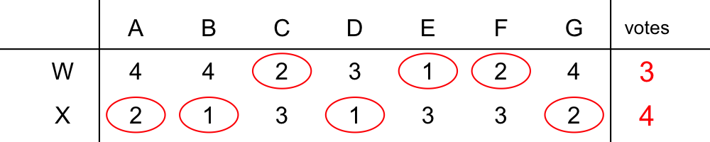

So, X beats W.

Compare candidates W and Y.

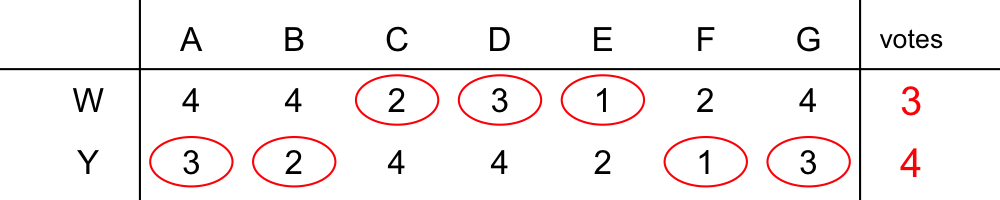

So, Y beats W.

Compare candidates W and Z.

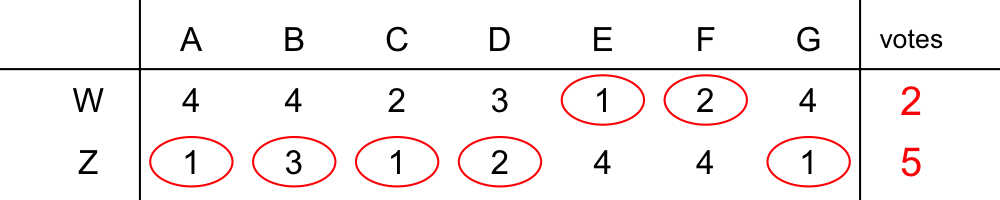

So, Z beats W.

Compare candidates X and Y.

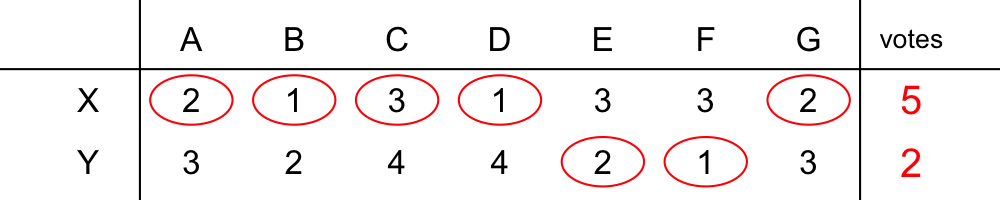

So, X beats Y.

Compare candidates X and Z.

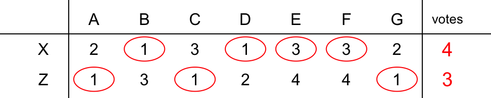

So, X beats Z.

Compare candidates Y and Z.

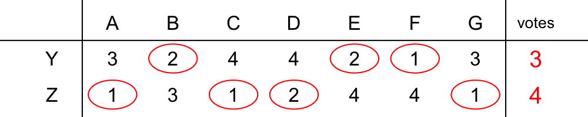

So, Z beats Y.

Organize all this into a winner table.

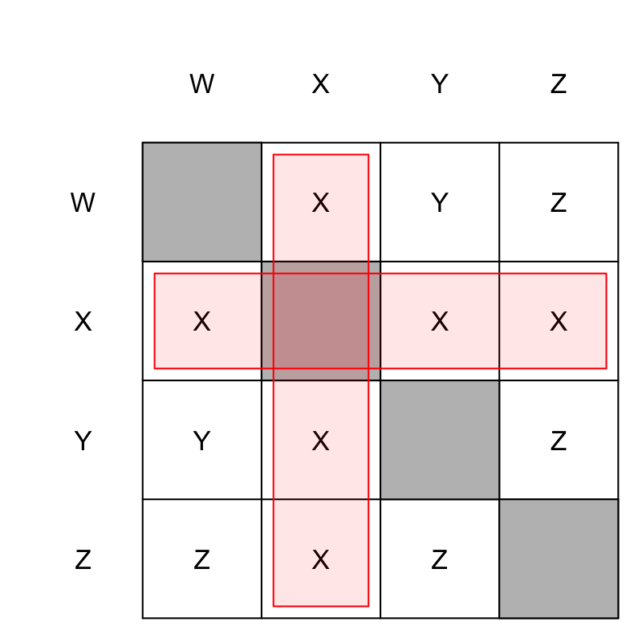

Notice X wins against all other candidates. Thus X is the Condorcet winner.

In Adams, Massachusetts, 4 candidates (W through Z) are running in an election with a single winner. There are 7 voters (A through G) who each rank the candidates from 1 to 4, with 1 meaning first choice and 4 meaning last choice. Those rankings are shown below. Each column represents a single voter's ranking.

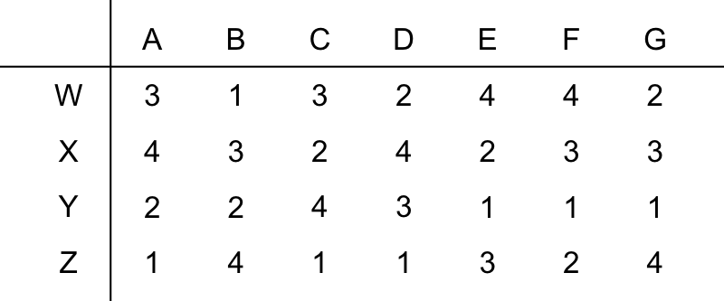

A [Condorcet winner](https://en.wikipedia.org/wiki/Condorcet_method) would win in a head-to-head election against any other candidate. Who is the Condorcet winner? (Or, possibly, there is none.)

WXYZNo Condorcet winner!

Consider every head-to-head election. With 4 candidates, there will be ${4\choose 2 }= 6$ pairings (see [combinations](https://en.wikipedia.org/wiki/Binomial_coefficient)).

Compare candidates W and X.

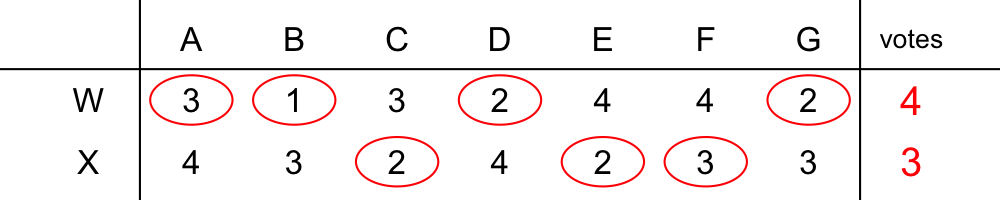

So, W beats X.

Compare candidates W and Y.

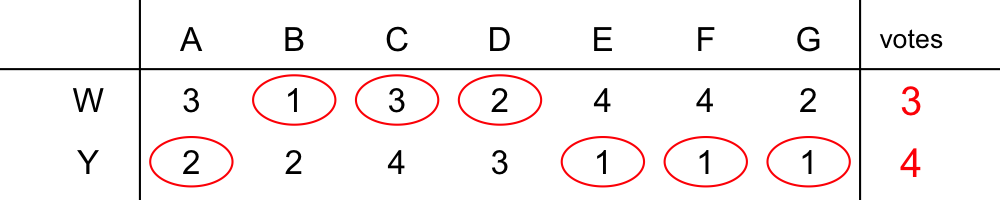

So, Y beats W.

Compare candidates W and Z.

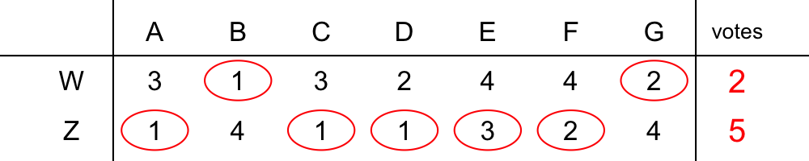

So, Z beats W.

Compare candidates X and Y.

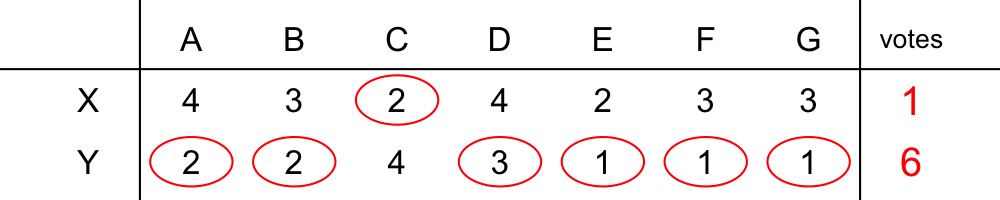

So, Y beats X.

Compare candidates X and Z.

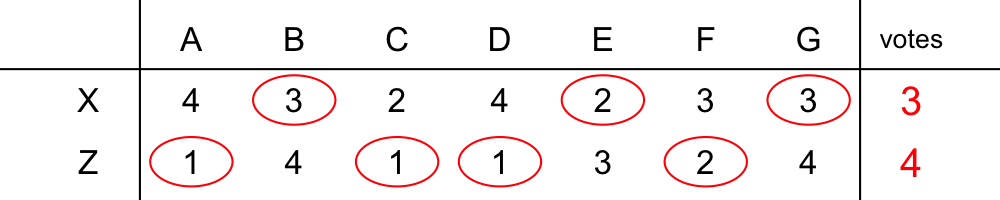

So, Z beats X.

Compare candidates Y and Z.

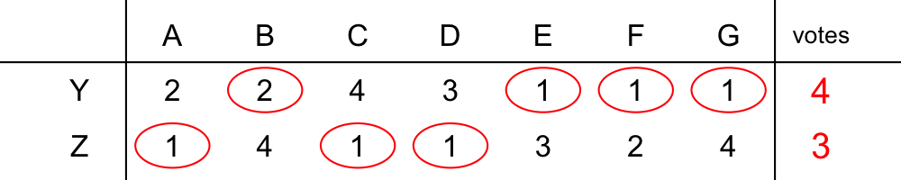

So, Y beats Z.

Organize all this into a winner table.

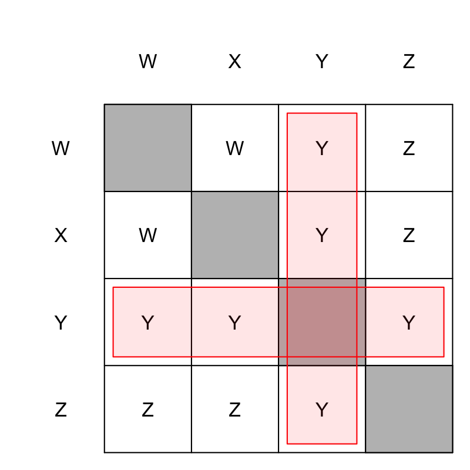

Notice Y wins against all other candidates. Thus Y is the Condorcet winner.

In Adams, Massachusetts, 4 candidates (W through Z) are running in an election with a single winner. There are 7 voters (A through G) who each rank the candidates from 1 to 4, with 1 meaning first choice and 4 meaning last choice. Those rankings are shown below. Each column represents a single voter's ranking.

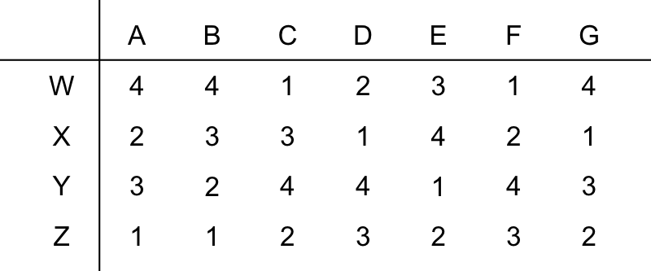

A [Condorcet winner](https://en.wikipedia.org/wiki/Condorcet_method) would win in a head-to-head election against any other candidate. Who is the Condorcet winner? (Or, possibly, there is none.)

WXYZNo Condorcet winner!

Consider every head-to-head election. With 4 candidates, there will be ${4\choose 2 }= 6$ pairings (see [combinations](https://en.wikipedia.org/wiki/Binomial_coefficient)).

Compare candidates W and X.

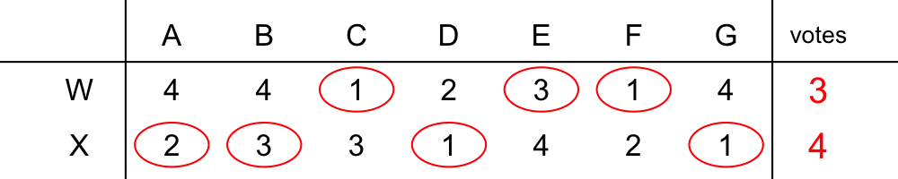

So, X beats W.

Compare candidates W and Y.

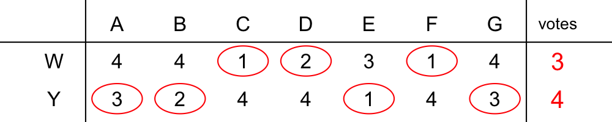

So, Y beats W.

Compare candidates W and Z.

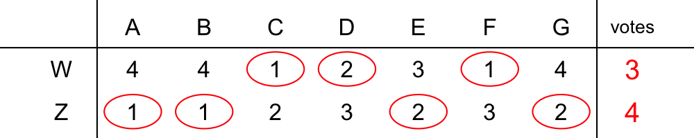

So, Z beats W.

Compare candidates X and Y.

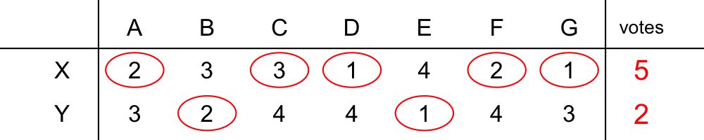

So, X beats Y.

Compare candidates X and Z.

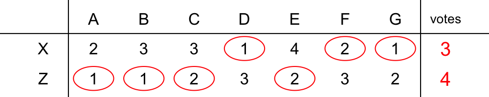

So, Z beats X.

Compare candidates Y and Z.

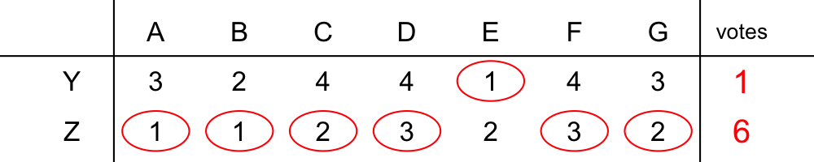

So, Z beats Y.

Organize all this into a winner table.

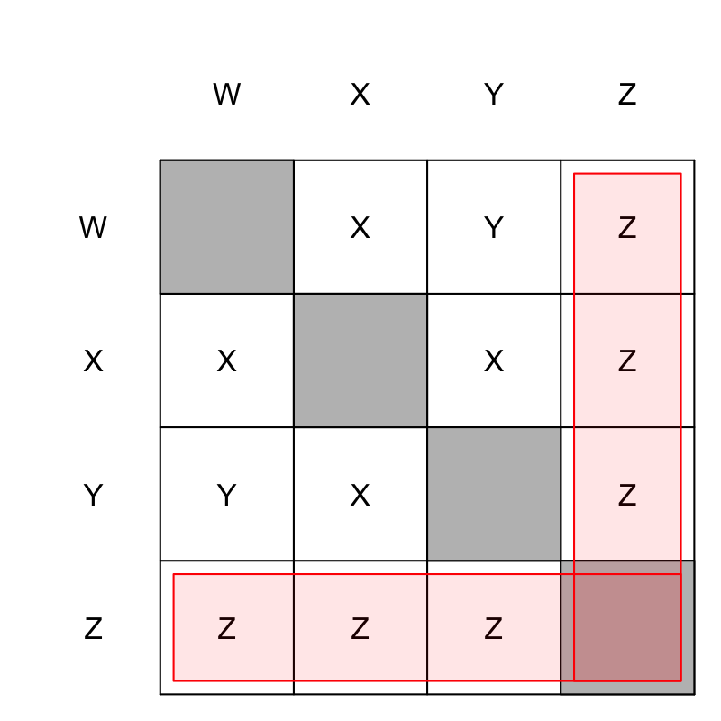

Notice Z wins against all other candidates. Thus Z is the Condorcet winner.

In Adams, Massachusetts, 4 candidates (W through Z) are running in an election with a single winner. There are 7 voters (A through G) who each rank the candidates from 1 to 4, with 1 meaning first choice and 4 meaning last choice. Those rankings are shown below. Each column represents a single voter's ranking.

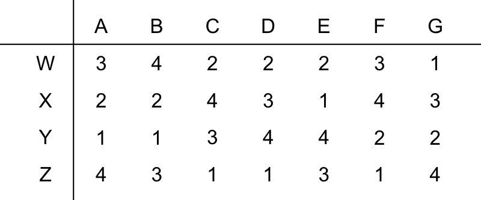

A [Condorcet winner](https://en.wikipedia.org/wiki/Condorcet_method) would win in a head-to-head election against any other candidate. Who is the Condorcet winner? (Or, possibly, there is none.)

WXYZNo Condorcet winner!

Consider every head-to-head election. With 4 candidates, there will be ${4\choose 2 }= 6$ pairings (see [combinations](https://en.wikipedia.org/wiki/Binomial_coefficient)).

Compare candidates W and X.

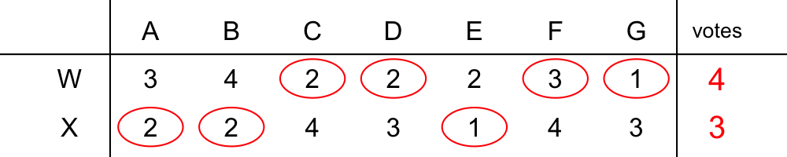

So, W beats X.

Compare candidates W and Y.

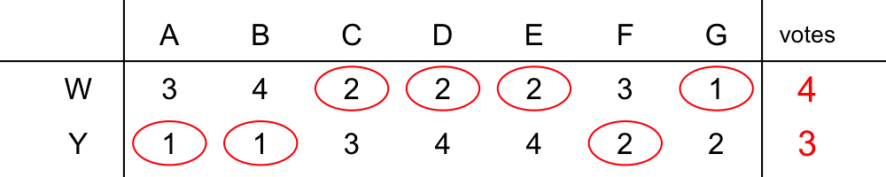

So, W beats Y.

Compare candidates W and Z.

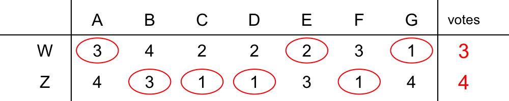

So, Z beats W.

Compare candidates X and Y.

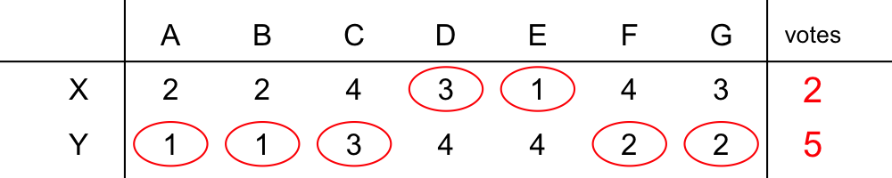

So, Y beats X.

Compare candidates X and Z.

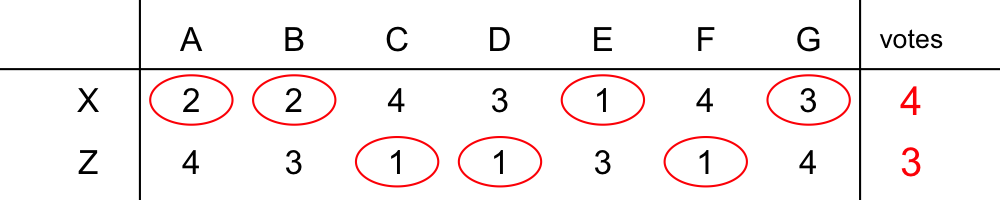

So, X beats Z.

Compare candidates Y and Z.

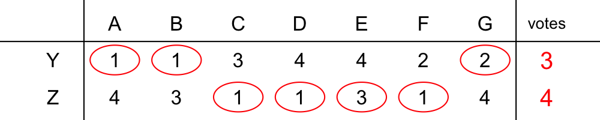

So, Z beats Y.

Organize all this into a winner table.

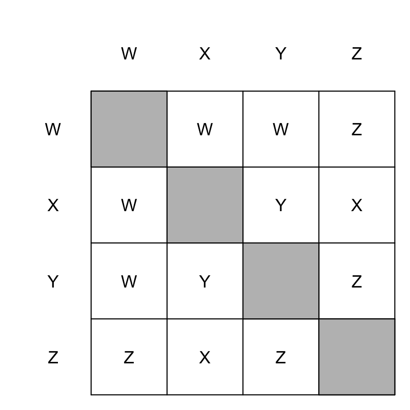

No candidate wins against every other candidate. There is no Condorcet winner.

In Adams, Massachusetts, 4 candidates (W through Z) are running in an election with a single winner. There are 7 voters (A through G) who each rank the candidates from 1 to 4, with 1 meaning first choice and 4 meaning last choice. Those rankings are shown below. Each column represents a single voter's ranking.

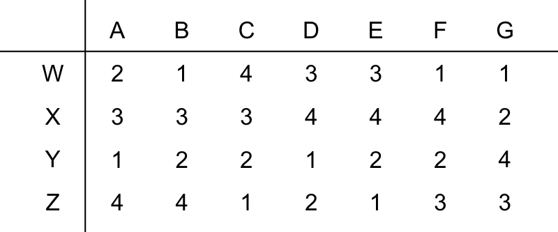

A [Condorcet winner](https://en.wikipedia.org/wiki/Condorcet_method) would win in a head-to-head election against any other candidate. Who is the Condorcet winner? (Or, possibly, there is none.)

WXYZNo Condorcet winner!

Consider every head-to-head election. With 4 candidates, there will be ${4\choose 2 }= 6$ pairings (see [combinations](https://en.wikipedia.org/wiki/Binomial_coefficient)).

Compare candidates W and X.

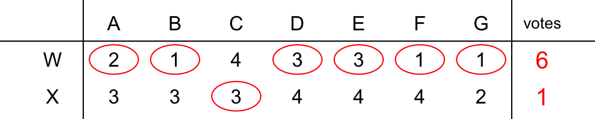

So, W beats X.

Compare candidates W and Y.

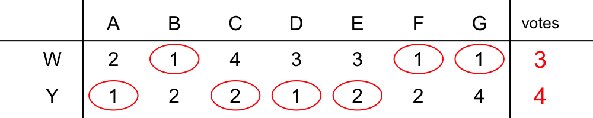

So, Y beats W.

Compare candidates W and Z.

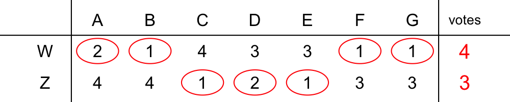

So, W beats Z.

Compare candidates X and Y.

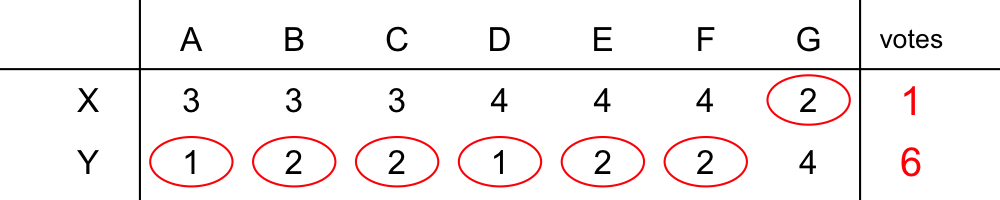

So, Y beats X.

Compare candidates X and Z.

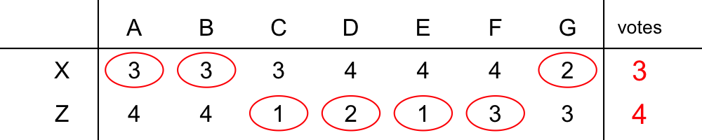

So, Z beats X.

Compare candidates Y and Z.

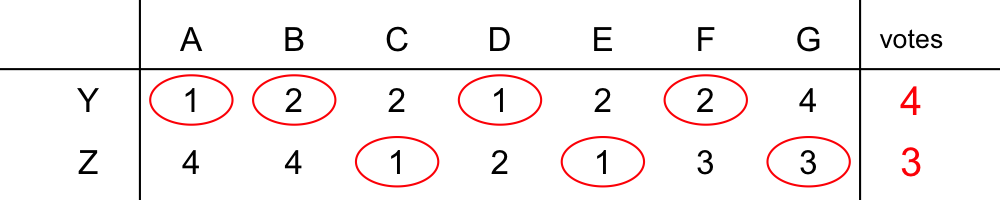

So, Y beats Z.

Organize all this into a winner table.

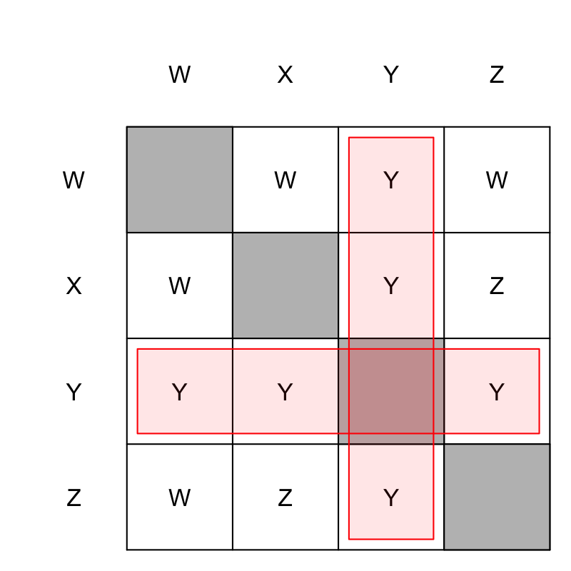

Notice Y wins against all other candidates. Thus Y is the Condorcet winner.

In Adams, Massachusetts, 4 candidates (W through Z) are running in an election with a single winner. There are 6 voters (A through F) who each rank the candidates from 1 to 4, with 1 meaning first choice and 4 meaning last choice. Those rankings are shown below. Each column represents a single voter's ranking.

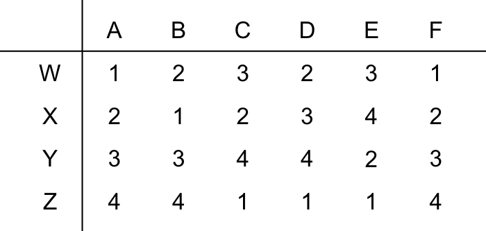

What [Borda count](https://en.wikipedia.org/wiki/Borda_count) would each candidate get?

- Borda count of candidate W:
- Borda count of candidate X:
- Borda count of candidate Y:
- Borda count of candidate Z:
- Who wins the Borda election?

There are 4 candidates. So, we subtract each preference number from 4 to get Borda points. We then add all the Borda points from each voter.

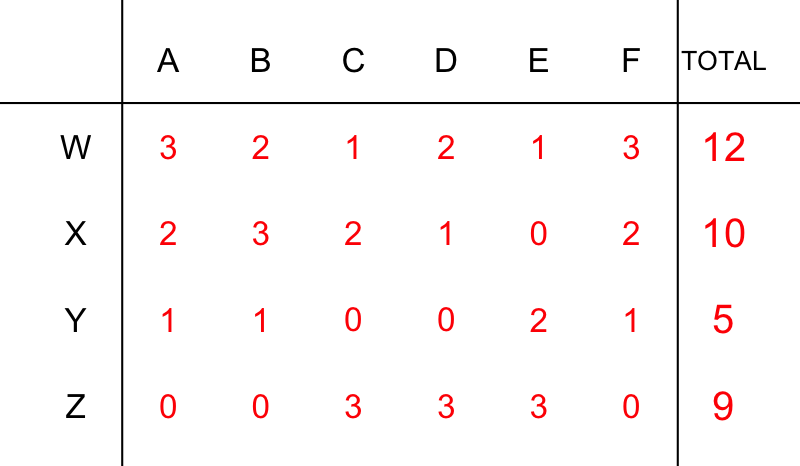

In Adams, Massachusetts, 4 candidates (W through Z) are running in an election with a single winner. There are 7 voters (A through G) who each rank the candidates from 1 to 4, with 1 meaning first choice and 4 meaning last choice. Those rankings are shown below. Each column represents a single voter's ranking.

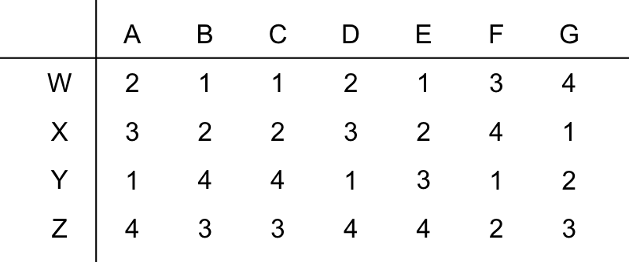

What [Borda count](https://en.wikipedia.org/wiki/Borda_count) would each candidate get?

- Borda count of candidate W:
- Borda count of candidate X:
- Borda count of candidate Y:
- Borda count of candidate Z:
- Who wins the Borda election?

There are 4 candidates. So, we subtract each preference number from 4 to get Borda points. We then add all the Borda points from each voter.

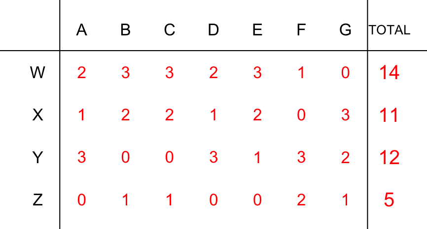

In Adams, Massachusetts, 4 candidates (W through Z) are running in an election with a single winner. There are 6 voters (A through F) who each rank the candidates from 1 to 4, with 1 meaning first choice and 4 meaning last choice. Those rankings are shown below. Each column represents a single voter's ranking.

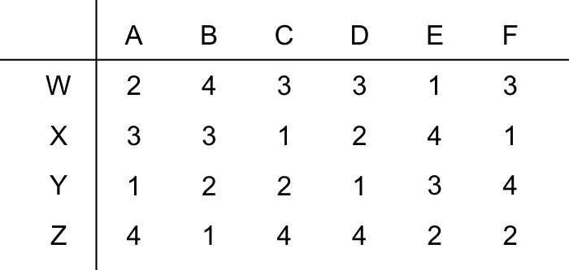

What [Borda count](https://en.wikipedia.org/wiki/Borda_count) would each candidate get?

- Borda count of candidate W:
- Borda count of candidate X:
- Borda count of candidate Y:
- Borda count of candidate Z:
- Who wins the Borda election?

There are 4 candidates. So, we subtract each preference number from 4 to get Borda points. We then add all the Borda points from each voter.

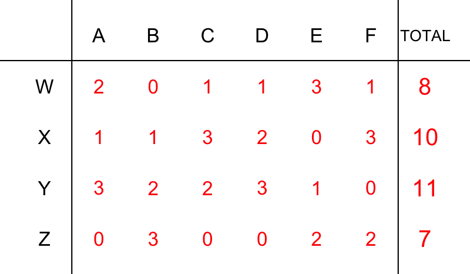

In Adams, Massachusetts, 4 candidates (W through Z) are running in an election with a single winner. There are 7 voters (A through G) who each rank the candidates from 1 to 4, with 1 meaning first choice and 4 meaning last choice. Those rankings are shown below. Each column represents a single voter's ranking.

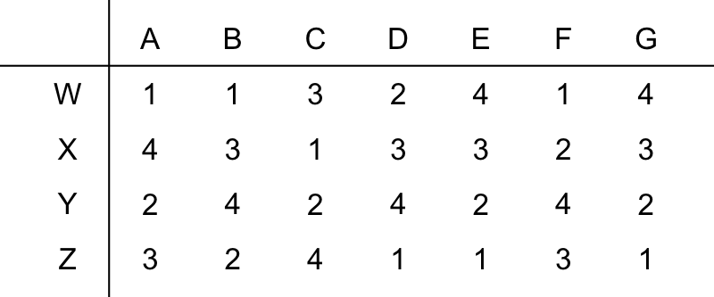

What [Borda count](https://en.wikipedia.org/wiki/Borda_count) would each candidate get?

- Borda count of candidate W:
- Borda count of candidate X:
- Borda count of candidate Y:
- Borda count of candidate Z:
- Who wins the Borda election?

There are 4 candidates. So, we subtract each preference number from 4 to get Borda points. We then add all the Borda points from each voter.

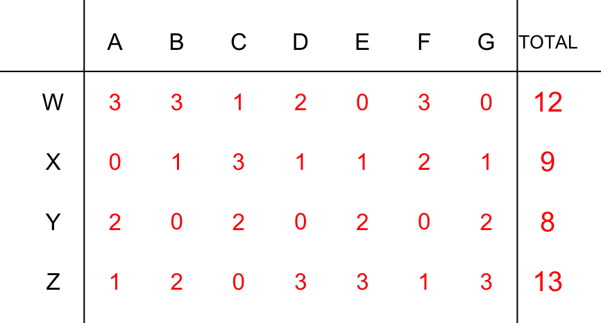

In Adams, Massachusetts, 5 candidates (V through Z) are running in an election with a single winner. There are 7 voters (A through G) who each rank the candidates from 1 to 5, with 1 meaning first choice and 5 meaning last choice. Those rankings are shown below. Each column represents a single voter's ranking.

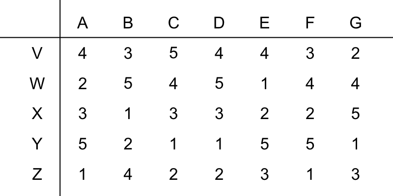

What [Borda count](https://en.wikipedia.org/wiki/Borda_count) would each candidate get?

- Borda count of candidate V:
- Borda count of candidate W:
- Borda count of candidate X:
- Borda count of candidate Y:
- Borda count of candidate Z:
- Who wins the Borda election?

There are 5 candidates. So, we subtract each preference number from 5 to get Borda points. We then add all the Borda points from each voter.

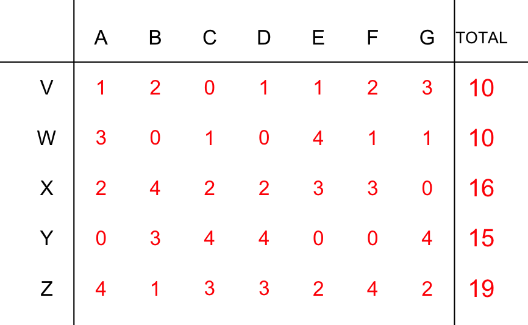

In Adams, Massachusetts, 5 candidates (V through Z) are running in an election with a single winner. There are 6 voters (A through F) who each rank the candidates from 1 to 5, with 1 meaning first choice and 5 meaning last choice. Those rankings are shown below. Each column represents a single voter's ranking.

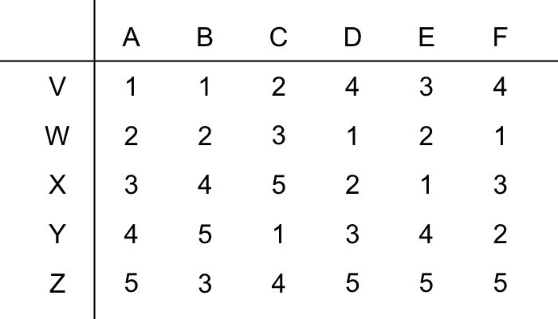

What [Borda count](https://en.wikipedia.org/wiki/Borda_count) would each candidate get?

- Borda count of candidate V:
- Borda count of candidate W:
- Borda count of candidate X:
- Borda count of candidate Y:
- Borda count of candidate Z:
- Who wins the Borda election?

There are 5 candidates. So, we subtract each preference number from 5 to get Borda points. We then add all the Borda points from each voter.

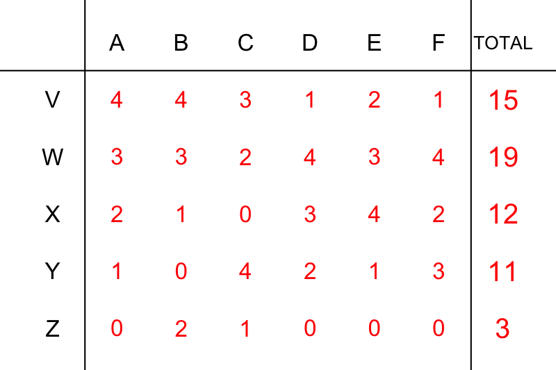

In Adams, Massachusetts, 5 candidates (V through Z) are running in an election with a single winner. There are 7 voters (A through G) who each rank the candidates from 1 to 5, with 1 meaning first choice and 5 meaning last choice. Those rankings are shown below. Each column represents a single voter's ranking.

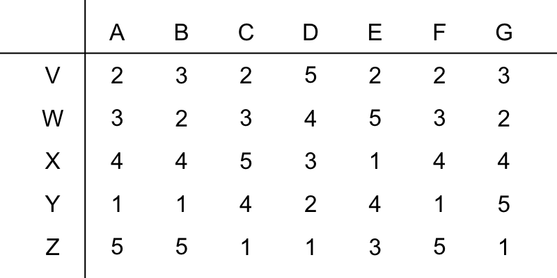

What [Borda count](https://en.wikipedia.org/wiki/Borda_count) would each candidate get?